# p8105_hw06_zy2392

Stephen Yuan

12/4/2021

## Problem 1

### Import data and tidy data

```r
bw_raw =
  read.csv("birthweight.csv") %>%
  janitor::clean_names() %>%
  drop_na() %>%
  mutate(
    babysex = factor(babysex, levels = c('1','2')),
    frace = factor(frace, levels = c('1','2','3','4','5','6','7','8','9')),
    mrace = factor(mrace, levels = c('1', '2', '3', '4', '8')),
    malform = factor(malform, levels = c('0', '1'))
  )
```

### Model fitting

#### Model selection

Use the **stepwise regression method** to select the best model.

```r
model_fit = lm(bwt ~ ., data = bw_raw) %>%
  step(direction = 'backward')
```

```
## Start:  AIC=48717.83
## bwt ~ babysex + bhead + blength + delwt + fincome + frace + gaweeks +
##     malform + menarche + mheight + momage + mrace + parity +
##     pnumlbw + pnumsga + ppbmi + ppwt + smoken + wtgain
##
##
## Step:  AIC=48717.83
## bwt ~ babysex + bhead + blength + delwt + fincome + frace + gaweeks +
##     malform + menarche + mheight + momage + mrace + parity +
##     pnumlbw + pnumsga + ppbmi + ppwt + smoken
##
##
## Step:  AIC=48717.83
## bwt ~ babysex + bhead + blength + delwt + fincome + frace + gaweeks +
##     malform + menarche + mheight + momage + mrace + parity +
##     pnumlbw + ppbmi + ppwt + smoken
##
##
## Step:  AIC=48717.83
## bwt ~ babysex + bhead + blength + delwt + fincome + frace + gaweeks +
##     malform + menarche + mheight + momage + mrace + parity +
##     ppbmi + ppwt + smoken
##
##            Df Sum of Sq       RSS   AIC
## - frace     4    124365 320848704 48712
## - malform   1      1419 320725757 48716
## - ppbmi     1      6346 320730684 48716
## - momage    1     28661 320752999 48716
## - mheight   1     66886 320791224 48717
## - menarche  1    111679 320836018 48717
## - ppwt      1    131132 320855470 48718
## <none>                  320724338 48718
## - fincome   1    193454 320917792 48718
## - parity    1    413584 321137922 48721
## - mrace     3    868321 321592659 48724
## - babysex   1    853796 321578134 48727
## - gaweeks   1   4611823 325336161 48778
## - smoken    1   5076393 325800732 48784
## - delwt     1   8008891 328733230 48823
## - blength   1 102050296 422774634 49915
```

[output cut: 88 more lines]

```
##     mheight + mrace + parity + ppwt + smoken
##
##           Df Sum of Sq       RSS   AIC
## <none>                 320986412 48705
## - fincome  1    245637 321232048 48707
## - parity   1    422770 321409181 48709
## - babysex  1    846134 321832545 48715
## - mheight  1   1012240 321998651 48717
## - ppwt     1   2907049 323893461 48743
## - gaweeks  1   4662501 325648912 48766
## - smoken   1   5073849 326060260 48771
## - delwt    1   8137459 329123871 48812
## - mrace    3  14683609 335670021 48894
## - blength  1 102191779 423178191 49903
## - bhead    1 106779754 427766166 49950
```

```r
summary(model_fit)
```

```
##
## Call:
## lm(formula = bwt ~ babysex + bhead + blength + delwt + fincome +
##     gaweeks + mheight + mrace + parity + ppwt + smoken, data = bw_raw)
##
## Residuals:
##      Min       1Q   Median       3Q      Max
## -1097.18  -185.52    -3.39   174.14  2353.44
##
## Coefficients:
##               Estimate Std. Error t value Pr(>|t|)
## (Intercept) -6098.8219   137.5463 -44.340  < 2e-16 ***
## babysex2       28.5580     8.4549   3.378 0.000737 ***
## bhead         130.7770     3.4466  37.944  < 2e-16 ***
## blength        74.9471     2.0190  37.120  < 2e-16 ***
## delwt           4.1067     0.3921  10.475  < 2e-16 ***
## fincome         0.3180     0.1747   1.820 0.068844 .
## gaweeks        11.5925     1.4621   7.929 2.79e-15 ***
## mheight         6.5940     1.7849   3.694 0.000223 ***
## mrace2       -138.7925     9.9071 -14.009  < 2e-16 ***
## mrace3        -74.8868    42.3146  -1.770 0.076837 .
## mrace4       -100.6781    19.3247  -5.210 1.98e-07 ***
## parity         96.3047    40.3362   2.388 0.017004 *
## ppwt           -2.6756     0.4274  -6.261 4.20e-10 ***
## smoken         -4.8434     0.5856  -8.271  < 2e-16 ***
## ---
## Signif. codes:  0 '***' 0.001 '**' 0.01 '*' 0.05 '.' 0.1 ' ' 1
##
## Residual standard error: 272.3 on 4328 degrees of freedom
## Multiple R-squared:  0.7181, Adjusted R-squared:  0.7173
## F-statistic: 848.1 on 13 and 4328 DF,  p-value: < 2.2e-16
```

**Modeling process:** The model selection process started with all variables, variables whose loss bring the most statistically insignificant effect on the model will be deleted, the process will repeat until no further variables deleted could be deleted.

#### Residual plots

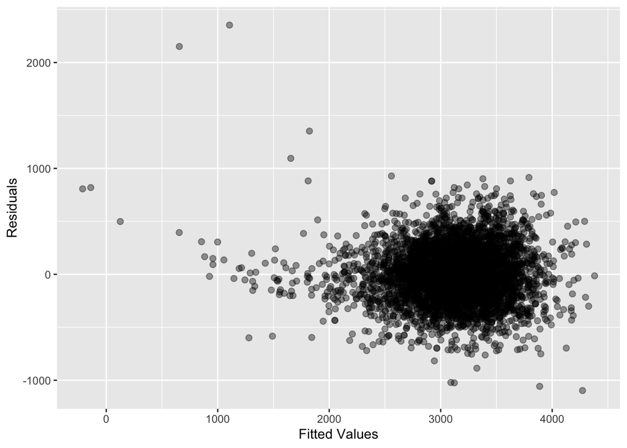

```r
bw_raw %>%
  add_predictions(model_fit) %>%
  add_residuals(model_fit) %>%
  ggplot(aes(x = pred, y = resid)) +
  geom_point(alpha = .4, size = 2) +
  xlab("Fitted Values") +
  ylab("Residuals")
```

**Comment:** residuals are centered around 0, however, there is limited amount of outliers.

#### Two other models

main effects only

```r
model_1 = lm(bwt ~ blength + gaweeks, data = bw_raw)

model_1 %>%
  broom::tidy() %>%
  knitr::kable(digits = 3)
```

| term | estimate | std.error | statistic | p.value |
| --- | --- | --- | --- | --- |
| (Intercept) | -4347.667 | 97.958 | -44.383 | 0 |
| blength | 128.556 | 1.990 | 64.604 | 0 |
| gaweeks | 27.047 | 1.718 | 15.744 | 0 |

including three-way interactions

```r
model_2 = lm(bwt ~ bhead * blength * babysex, data = bw_raw)

model_2 %>%
  broom::tidy() %>%
  knitr::kable(digits = 3)
```

| term | estimate | std.error | statistic | p.value |
| --- | --- | --- | --- | --- |
| (Intercept) | -7176.817 | 1264.840 | -5.674 | 0.000 |
| bhead | 181.796 | 38.054 | 4.777 | 0.000 |
| blength | 102.127 | 26.212 | 3.896 | 0.000 |
| babysex2 | 6374.868 | 1677.767 | 3.800 | 0.000 |
| bhead:blength | -0.554 | 0.780 | -0.710 | 0.478 |
| bhead:babysex2 | -198.393 | 51.092 | -3.883 | 0.000 |
| blength:babysex2 | -123.773 | 35.119 | -3.524 | 0.000 |
| bhead:blength:babysex2 | 3.878 | 1.057 | 3.670 | 0.000 |

make comparisons using cross validation

```r
cv_df =
  crossv_mc(bw_raw, 100) %>%
  mutate(
    train = map(train, as_tibble),
    test = map(test, as_tibble)
    ) %>%
  mutate(model1  = map(train, ~lm(bwt ~ babysex + bhead + blength + delwt + fincome + gaweeks + mheight + mrace + parity + ppwt + smoken, data = .x)),
         model2  = map(train, ~lm(bwt ~ blength + gaweeks, data = .x)),
         model3  = map(train, ~lm(bwt ~ bhead * blength * babysex, data = .x))) %>%
  mutate(rmse_model1 = map2_dbl(model1, test, ~rmse(model = .x, data = .y)),
         rmse_model2 = map2_dbl(model2, test, ~rmse(model = .x, data = .y)),
         rmse_model3 = map2_dbl(model3, test, ~rmse(model = .x, data = .y)))
```

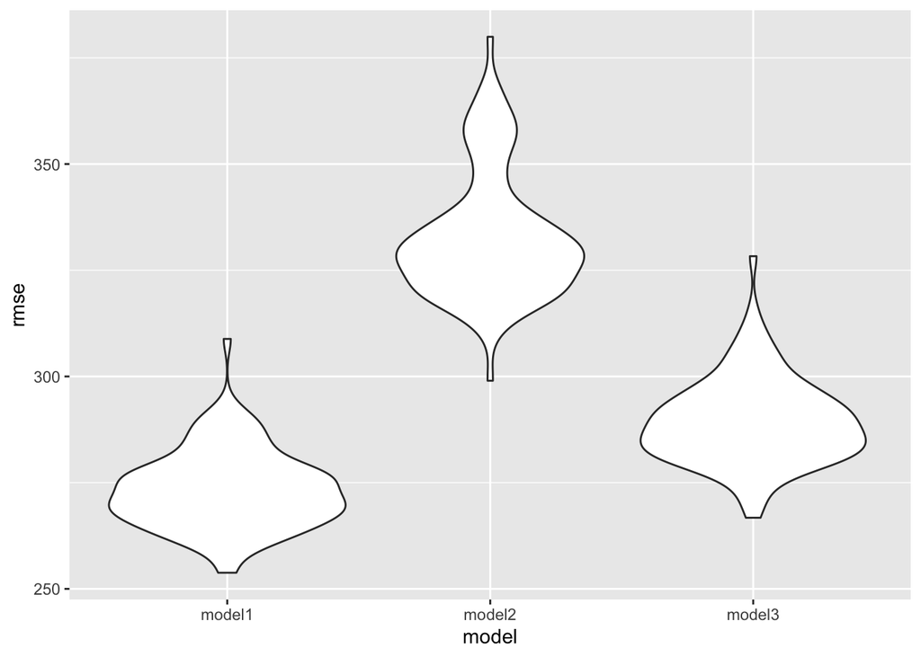

```r
cv_df %>%
  select(starts_with("rmse")) %>%
  pivot_longer(
    everything(),
    names_to = "model",
    values_to = "rmse",
    names_prefix = "rmse_") %>%
  mutate(model = fct_inorder(model)) %>%
  ggplot(aes(x = model, y = rmse)) + geom_violin()
```

We can see from the plots, model 1 had the lowest root-mean-square error and model 2 had the largest root-mean-square error. Thus, model 1 had the best performance whereas model 2 had the worst performance, among all three models.

## Problem 2

### Import dataset

```r
weather_df =
  rnoaa::meteo_pull_monitors(
    c("USW00094728"),
    var = c("PRCP", "TMIN", "TMAX"),
    date_min = "2017-01-01",
    date_max = "2017-12-31") %>%
  mutate(
    name = recode(id, USW00094728 = "CentralPark_NY"),
    tmin = tmin / 10,
    tmax = tmax / 10) %>%
  select(name, id, everything())
```

```
## using cached file: ~/Library/Caches/R/noaa_ghcnd/USW00094728.dly
```

```
## date created (size, mb): 2021-11-19 23:12:56 (7.613)
```

```
## file min/max dates: 1869-01-01 / 2021-11-30
```

```r
boot_sample = function(df) {

  sample_frac(df, replace = TRUE)

}
```

### Analyzing R squared.

```r
boot_straps =
  data_frame(
    strap_number = 1:5000,
    strap_sample = rerun(5000, boot_sample(weather_df))
  )
```

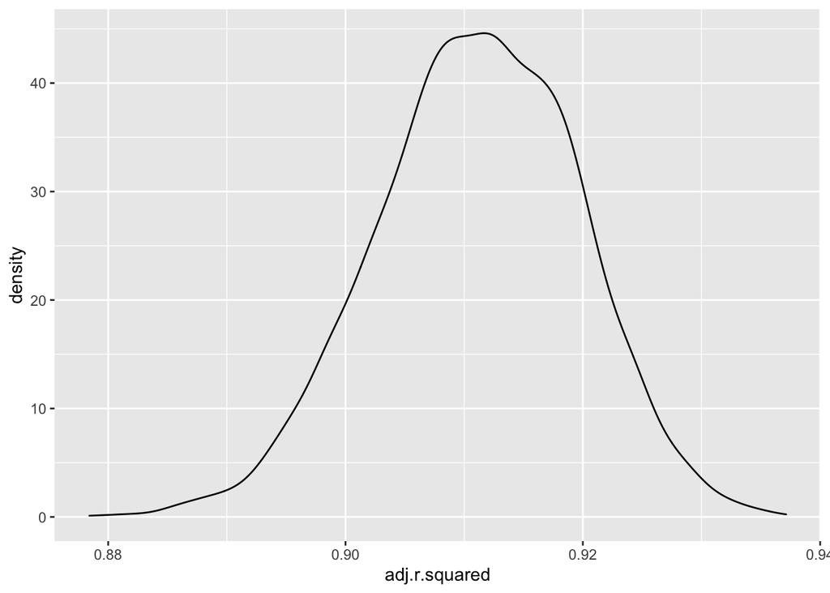

```r
bootstrap_results_1 =
  boot_straps %>%
  mutate(
    models = map(strap_sample, ~lm(tmax ~ tmin, data = .x) ),
    results = map(models, broom::glance)) %>%
  select(-strap_sample, -models) %>%
  unnest(results)
bootstrap_results_1 %>%
  ggplot(aes(x = adj.r.squared)) +
  geom_density()
```

From the plot of adjusted R square, we can see that its distribution looks like normal distribution, with a peak between 0.90 and 0.92.

The 95% CI of adjusted R square is: (0.8937625 , 0.9269499).

### Analyzing log of the product of betas.

```r
log_beta_p = function(df) {
    log(df[1,2]*df[2,2]) %>%
    tibble() %>%
    mutate(
      log_betas=.$estimate) %>%
    select(log_betas)
}
```

```r
bootstrap_results_2=
  boot_straps %>%
  mutate(
    models = map(strap_sample, ~lm(tmax ~ tmin, data = .x) ),
    results = map(models, broom::tidy),
    log_betas = map(results, log_beta_p)) %>%
  select(-strap_sample, -models) %>%
  unnest(log_betas)
```

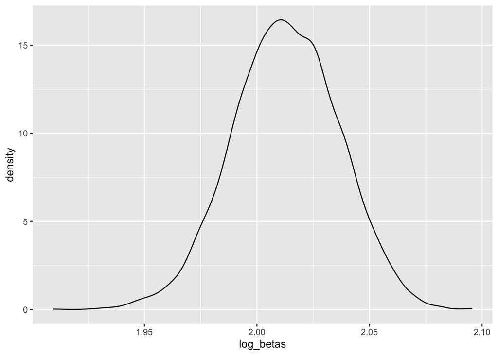

```r
bootstrap_results_2 %>%
  ggplot(aes(x = log_betas)) +
  geom_density()
```

From the plot of log of the product of betas, we can see that its distribution also looks like normal distribution, with a peak between 2.00 and 2.025.

The 95% CI of log of the product of betas is: (1.9661019 , 2.0575605).